# Prediction of Coronary Heart Disease by learning from retrospective study

## By: Srisai Sivakumar, aka, the data science dude.

### Introduction

Coronary heart disease (CHD) is the term that describes what happens when your heart's blood supply is blocked or interrupted by a build-up of fatty substances in the coronary arteries.

[NHS](http://www.nhs.uk/conditions/Coronary-heart-disease/Pages/Introduction.aspx) states that Coronary heart disease can't be cured but treatment can help manage the symptoms and reduce the chances of problems such as heart attacks. Treatment can include lifestyle changes, such as regular exercise and stopping smoking, as well as medication and surgery.

Given that there is not cure for CHD, prevention presents the best way to combat CHD. The potential factors influencing prevention are a mix including (but not exclusive to) biological, hereditary factors, lifestyle choices.

We make use of a data containing some such factors of a particular sample of population and try to examine of the data can be generalized to a larger population. The goal of this study is to make use to available data on CHD and determine which of the factors are siginiicant contributors to CHD.

### The data

The data set describes a retrospective sample of males in a high-risk heart-disease region of the Western Cape in South Africa. A total of 462 samples are included in this data set.

Each high-risk patient has been monitored and the following patient attributes were obtained:

- Systolic Blood Pressure (sbp): [The blood pressure when the heart is contracting. It is specifically the maximum arterial pressure during contraction of the left ventricle of the heart. The time at which ventricular contraction occurs is called systole](http://www.medicinenet.com/script/main/art.asp?articlekey=16163). In a blood pressure reading, the systolic pressure is typically the first number recorded. For example, with a blood pressure of 120/80 (“120 over 80”), the systolic pressure is 120. By “120” is meant 120 mm Hg (millimeters of mercury).
- Cumulative Tobacco (tobacco) usage (kg)
- Low Density Lipoprotein Cholesterol (ldl): often referred to as the 'bad' cholestrol.
- Adiposity: Body adiposity index determines body fat percentage. It is a measure of the percentage of total body mass that is composed of fat (as opposed to fat-free mass which includes everything else other than fat that makes up the body). Its calculated as (HC / (HM)<sup>1.5)</sup> - 18, where HC = Hip Circumference in Centimetres and HM = Height in meters. More details can be found [here](http://www.shapesense.com/fitness-exercise/calculators/body-adiposity-index-calculator.aspx)
- Family history of heart disease (famhist): History of CHD within subject's family
- Type-A behavior (typea): Type A personality theory describes personality type that could raise one's chances of developing coronary heart disease. [Wikipedia](https://en.wikipedia.org/wiki/Type_A_and_Type_B_personality_theory) describes “Type A” individuals as ambitious, rigidly organized, highly status-conscious, sensitive, impatient, take on more than they can handle, want other people to get to the point, anxious, proactive, and concerned with time management. People with Type A personalities are often high-achieving “workaholics” who multi-task, push themselves with deadlines, and hate both delays and ambivalence. Wiki also claims that “It is (therefore) understood that Type A personalities are suited to smoking as a mechanism for relieving stress”, but as a non medical professional, I can neither vouch nor reject this claim. I remain neutral to this claim and stick to the data collected durig the study which presents a quantification of this Type A personality.
- Obesity: represented by Body Mass Index (BMI)- is a value derived from the mass (weight) and height of an individual. BMI is defined as the body mass divided by the square of the body height, and is universally expressed in units of kg/m2, resulting from weight in kilograms and height in metres.
- Alcohol: current alcohol consumption
- Age

### Exploratory Analysis

```
## [1] "Dimensions of raw data are: "
```

```
## [1] 462  10
```

```
## [1] "Structure of data frame:"
```

```
## 'data.frame':    462 obs. of  10 variables:
##  $ sbp      : int  160 144 118 170 134 132 142 114 114 132 ...
##  $ tobacco  : num  12 0.01 0.08 7.5 13.6 6.2 4.05 4.08 0 0 ...
##  $ ldl      : num  5.73 4.41 3.48 6.41 3.5 6.47 3.38 4.59 3.83 5.8 ...
##  $ adiposity: num  23.1 28.6 32.3 38 27.8 ...
##  $ famhist  : Factor w/ 2 levels "Absent","Present": 2 1 2 2 2 2 1 2 2 2 ...
##  $ typea    : int  49 55 52 51 60 62 59 62 49 69 ...
##  $ obesity  : num  25.3 28.9 29.1 32 26 ...
##  $ alcohol  : num  97.2 2.06 3.81 24.26 57.34 ...
##  $ age      : int  52 63 46 58 49 45 38 58 29 53 ...
##  $ chd      : Factor w/ 2 levels "no","yes": 2 2 1 2 2 1 1 2 1 2 ...
```

```
## [1] "Count of chd and non-chd cases"
```

```
##
##  no yes
## 302 160
```

```
## [1] "Proportion of chd and non-chd cases"
```

```
##
##        no       yes
## 0.6536797 0.3463203
```

The case has close to 65% of cases with no CHD and 35% with CHD. So any model we build should give prediction accuracy greater than 65%.

Lets beging by looking at the pairwise relationship to begin with.

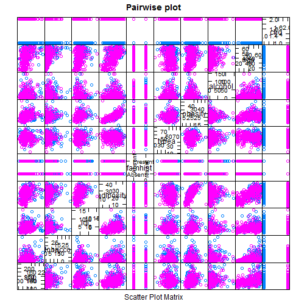

While this is too crowded to infer much from, we look at the correlation plot.

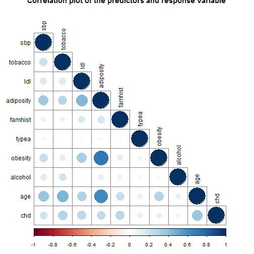

```
## [1] "4  of the predictors have a correlation of over 0.7"
```

We clearly see strong correlation among obesity and adiposity.

Lets begin by exploring the effect of tobacco and alcohol CHD.

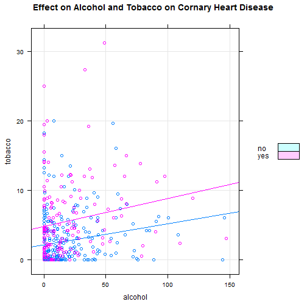

Quite clearly, there is a visible difference in the trends of presence and absence of CHD. Its important to understand if it is tobacco or alcohol or combined effect thats causing the clear difference in trend.

Lets first look at the agewise breakdown of the presence/absence of CHD, and then look at the effect of tobacco and alcohol with an agewise breakdown.

```
## [1] "Age wise breakdown of presence/absence CHD"
```

```
##
##            no yes
##   (0,20]   54   2
##   (20,30]  46   6
##   (30,40]  57  23
##   (40,50]  69  33
##   (50,60]  54  69
##   (60,70]  22  27
##   (70,80]   0   0
##   (80,90]   0   0
##   (90,100]  0   0
```

```
## [1] "Its important to note that there are too few observations in CHD cases for the age groups of 0-20 and 20-30"
```

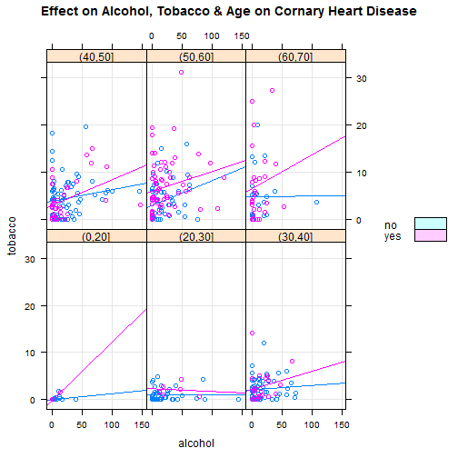

In the age groups of [0-20] and [20-30], we observe, understandibly, low number of CHD cases. Hence the red lines of these 2 sets cannot be taken seriously. Conclusively, its difficult to observe any visible trend with the effect of alcohol.

Lets look at the individual plots for alcohol and tobacco individually against age.

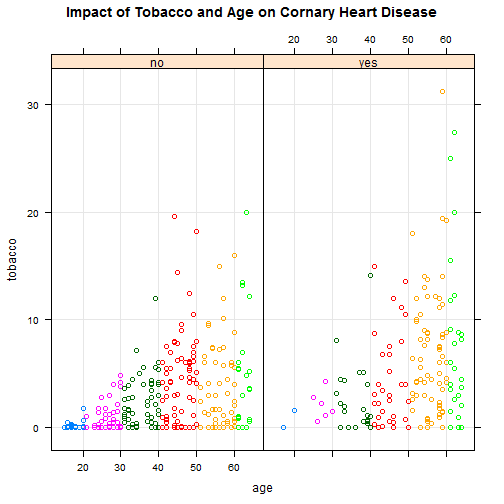

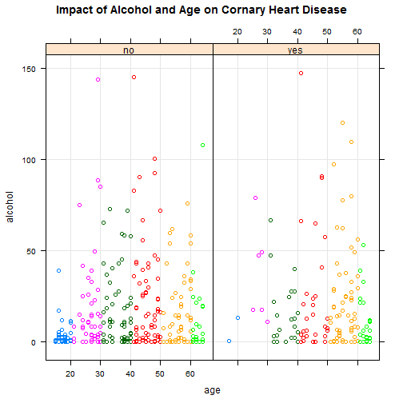

This makes it very clear that tobacco has a definitive effect on CHD, while alcohol doesnt seem to have much effect on CHD.

Lets look at other factors like family history.

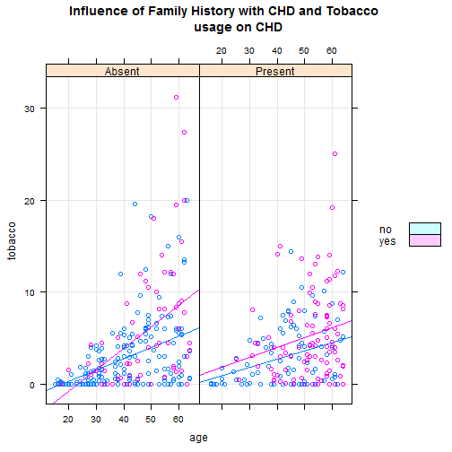

```
##          chd
## famhist    no yes
##   Absent  206  64
##   Present  96  96
```

```
##          chd
## famhist     no  yes
##   Absent  0.45 0.14
##   Present 0.21 0.21
```

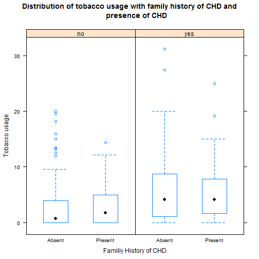

The table shows that there are more proportion of CHD cases with family history than those without. The plot also shows that that the CHD cases have high tobacco consumption irrespective of family history. This asserts the belief that a individual consumes tobacco as much tobacco as he/she does, irrespective of the prevalence of CHD in their family. And we have already seen that tobacco has influence on prevalence of CHD among individuals.

### Modelling

We split the data into training and test sets with a 70/30 split.

```
## [1] "dimensions of of training data:"
```

```
## [1] 324  10
```

```
## [1] "dimensions of of test data:"
```

```
## [1] 138  10
```

#### CART

We being with a CART model, to make use of its interpretability. If the accuracy it provides seem inadequate, we could explore other models. We use no specific tuning parameters to develop the model.

```
## [1] "Confusion Matrix"
```

```
## Confusion Matrix and Statistics
##
##           Reference
## Prediction no yes
##        no  66  24
##        yes 22  26
##
##                Accuracy : 0.6667
##                  95% CI : (0.5814, 0.7446)
##     No Information Rate : 0.6377
##     P-Value [Acc > NIR] : 0.2694
##
##                   Kappa : 0.2724
##  Mcnemar's Test P-Value : 0.8828
##
##             Sensitivity : 0.7500
##             Specificity : 0.5200
##          Pos Pred Value : 0.7333
##          Neg Pred Value : 0.5417
##              Prevalence : 0.6377
##          Detection Rate : 0.4783
##    Detection Prevalence : 0.6522
##       Balanced Accuracy : 0.6350
##
##        'Positive' Class : no
##
```

```
## [1] "The CART model gives an accuracy of: 0.667"
```

```
## [1] "Tree visualization"
```

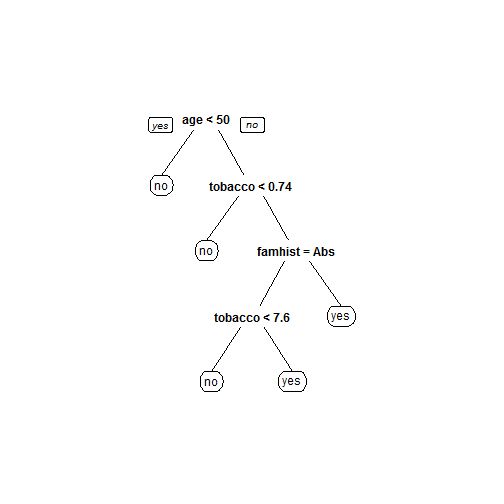

The increase in accuracy is pretty modest. So we would have to explore other models to improve the predictive accuracy.

But it would be interesting to briefly explore the decision tree of the CART model. The model predicts age, tobacco and famhist as the predictors of CHD. Whats intriuging is the fact that the decision tree is predicting a yes for CHD when there is no family history of CHD. As counter-intuitive as it is, we have seen this in the exploratory graphs. So we dont investigate this any further.

#### Logistic Regression

We move on to Logistic Regression. We are trying to seek improvement in predictive accuracy at the cost of interpretability. Clearly the tree provides a better way to communicate the decision making process to a HCP, than the set of regression coefficients given by Logistic Regression.

```
## [1] "Logistic Regression Model"
```

```
##
## Call:
## NULL
##
## Deviance Residuals:
##     Min       1Q   Median       3Q      Max
## -1.7409  -0.7964  -0.4259   0.8616   2.3344
##
## Coefficients:
##                  Estimate Std. Error z value Pr(>|z|)
## (Intercept)    -5.1034275  1.5949198  -3.200 0.001375 **
## sbp             0.0093808  0.0066582   1.409 0.158862
## tobacco         0.0867907  0.0330339   2.627 0.008606 **
## ldl             0.1593611  0.0678684   2.348 0.018870 *
## adiposity       0.0189747  0.0356023   0.533 0.594059
## famhistPresent  0.9443639  0.2743640   3.442 0.000577 ***
## typea           0.0411350  0.0145740   2.822 0.004765 **
## obesity        -0.1215069  0.0557379  -2.180 0.029260 *
## alcohol        -0.0006746  0.0050688  -0.133 0.894123
## age             0.0459560  0.0143998   3.191 0.001416 **
## ---
## Signif. codes:  0 '***' 0.001 '**' 0.01 '*' 0.05 '.' 0.1 ' ' 1
##
## (Dispersion parameter for binomial family taken to be 1)
##
##     Null deviance: 417.79  on 323  degrees of freedom
## Residual deviance: 326.28  on 314  degrees of freedom
## AIC: 346.28
##
## Number of Fisher Scoring iterations: 5
```

```
## [1] "Confusion Matrix"
```

```
## Confusion Matrix and Statistics
##
##           Reference
## Prediction no yes
##        no  75  15
##        yes 26  22
##
##                Accuracy : 0.7029
##                  95% CI : (0.6192, 0.7776)
##     No Information Rate : 0.7319
##     P-Value [Acc > NIR] : 0.8075
##
##                   Kappa : 0.3081
##  Mcnemar's Test P-Value : 0.1183
##
##             Sensitivity : 0.7426
##             Specificity : 0.5946
##          Pos Pred Value : 0.8333
##          Neg Pred Value : 0.4583
##              Prevalence : 0.7319
##          Detection Rate : 0.5435
##    Detection Prevalence : 0.6522
##       Balanced Accuracy : 0.6686
##
##        'Positive' Class : no
##
```

```
## [1] "The Logistic Regression model gives an accuracy of: 0.703"
```

From the summary of the logistic regression mode, we can observe that Systolic Blood Pressure (sbp), Alcohol and Adiposity are not significant predictors.

We can readily explain the in-significance of adiposity to the model. Its because of its correlation with obesity.

We have also seen that alcohol doesnt seem to be a significant predictor of CHD from our exploratory analysis.

The insignificance of Systolic Blood Pressure (sbp) to the model needs more thought. It could be that sbp is correlated “reasonably” (~0.36) with both adiposity and age. Or it could be that it is geneuinely not significant to the prediction of chd.

#### Boosting

Lets look at boosting models.

```
## [1] "Boosting Model"
```

```
## Stochastic Gradient Boosting
##
## 324 samples
##   9 predictor
##   2 classes: 'no', 'yes'
##
## No pre-processing
## Resampling: Bootstrapped (25 reps)
##
## Summary of sample sizes: 324, 324, 324, 324, 324, 324, ...
##
## Resampling results across tuning parameters:
##
##   interaction.depth  n.trees  Accuracy   Kappa      Accuracy SD
##   1                   50      0.7061870  0.3175085  0.04216481
##   1                  100      0.7017273  0.3161906  0.03683025
##   1                  150      0.6982321  0.3120341  0.04265250
##   2                   50      0.6884186  0.2841461  0.03188991
##   2                  100      0.6855690  0.2889863  0.03286851
##   2                  150      0.6808039  0.2789935  0.03657193
##   3                   50      0.6870697  0.2871036  0.04277671
##   3                  100      0.6780516  0.2676480  0.03216605
##   3                  150      0.6668781  0.2471732  0.03832787
##   Kappa SD
##   0.09268153
##   0.08227104
##   0.09295494
##   0.07129932
##   0.07304977
##   0.07411934
##   0.08923020
##   0.06875690
##   0.07586397
##
## Tuning parameter 'shrinkage' was held constant at a value of 0.1
##
## Tuning parameter 'n.minobsinnode' was held constant at a value of 10
## Accuracy was used to select the optimal model using  the largest value.
## The final values used for the model were n.trees = 50, interaction.depth
##  = 1, shrinkage = 0.1 and n.minobsinnode = 10.
```

```
## [1] "Confusion Matrix"
```

```
## Confusion Matrix and Statistics
##
##           Reference
## Prediction no yes
##        no  77  13
##        yes 28  20
##
##                Accuracy : 0.7029
##                  95% CI : (0.6192, 0.7776)
##     No Information Rate : 0.7609
##     P-Value [Acc > NIR] : 0.95236
##
##                   Kappa : 0.2936
##  Mcnemar's Test P-Value : 0.02878
##
##             Sensitivity : 0.7333
##             Specificity : 0.6061
##          Pos Pred Value : 0.8556
##          Neg Pred Value : 0.4167
##              Prevalence : 0.7609
##          Detection Rate : 0.5580
##    Detection Prevalence : 0.6522
##       Balanced Accuracy : 0.6697
##
##        'Positive' Class : no
##
```

```
## [1] "The boosting model gives an accuracy of: 0.703"
```

```
## gbm variable importance
##
##           Overall
## tobacco   34.1641
## age       21.6234
## typea     12.6069
## ldl       12.2063
## famhist   11.9076
## sbp        8.3061
## obesity    4.7283
## adiposity  0.8506
## alcohol    0.0000
```

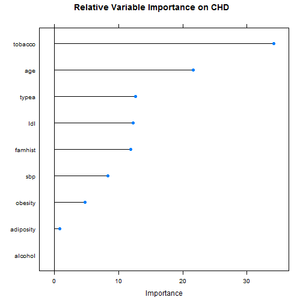

### Results

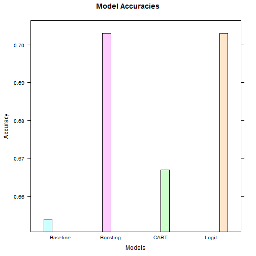

Preliminary exploratory analysis revealed that alcohol is not a significant predictor for CHD. This was later ascertained by CART, Logistic Regression and Boosting models. So it may be deduced that alcohol doesnot influence the occurrence of CHD.

While CART and Logistic Regression models deemed Systolic Blood Pressure (sbp) an insignificant predictor, Boosting partially reverses the trend by deeming it to be a significant predictor, at the expense of obesity and adiposity.

### Conclusion

The study investigates the application of various data mining algorithms to predict the heart attacks and to compare the best method of prediction. The results do not presents a dramatic difference in the prediction when using different classification algorithms like CART, Logistic Regression and Boosting. SUch a study can serve as an important tool to aid Doctors/Physicians to predict risky cases and advise accordingly, given that there is no cure for CHD.